# Final Project

Tools for Data Science

Author

Adasia McClinton

In this project you will be working with R, SQL, and Python in the same document. We will use the data sets *`airlines`* and *`flights`* from the package *`nycflights13`*.

1. *Render* the empty file (to make sure everything is working)
2. Consistently *Render* the file each time you answer a question

**In R, install the packages `nycflights13`, `sqldf`, `tidyverse` and load all of them and data sets `flights` and `airlines`**. Take your time to understand the data sets.

```r
# Install code here - comment the code when you finish installation
#install.packages(c("nycflights13","sqldf"))
#install.packages("reticulate")
# Load all package
library(tidyverse)
library(nycflights13)
library(sqldf)
library(reticulate)
library(dplyr)
#py_install("pandas")
#py_install("nycflights13")
#py_install("seaborn")
("matplotlib")
```

```
[1] "matplotlib"
```

```r
# Load the data
data(flights)
data(airlines)
```

## **Question 1: List the name of airlines where the destination is MIA airport with their *average arrival delays* and sort them from the smallest to largest average arrival delays. Use data frames `flights` and `airlines`.**

We shall solve this question using R, SQL, and Python.

### R solution

You can use the R command `inner_join()` to join two tables.

```r
# Joining flights and airlines data frames
joined_data <- inner_join(flights, airlines, by = "carrier")

# Filtering flights with destination MIA
mia_flights <- filter(joined_data, dest == "MIA")

# Calculating average arrival delay for each airline
average_delay <- mia_flights %>%
  group_by(name) %>%
  summarise(average_delay = mean(arr_delay, na.rm = TRUE)) %>%
  arrange(average_delay)

# Displaying the result
average_delay
```

```
# A tibble: 3 × 2
  name                   average_delay
  <chr>                          <dbl>
1 American Airlines Inc.         -1.88
2 Delta Air Lines Inc.            2.27
3 United Air Lines Inc.           6.66
```

### SQL solution

Write your SQL query in the function `sqldf()`. For example,`sqldf("select * from relig_income")` list all rows in the data frame `relig_income`.

```r
# Example
# sqldf("select * from relig_income limit 3")
sql_query <- "
  SELECT airlines.name, AVG(flights.arr_delay) AS average_delay
  FROM flights
  INNER JOIN airlines ON flights.carrier = airlines.carrier
  WHERE flights.dest = 'MIA'
  GROUP BY airlines.name
  ORDER BY average_delay
"

# Executing SQL query
sqldf(sql_query)
```

```
                    name average_delay
1 American Airlines Inc.     -1.878482
2   Delta Air Lines Inc.      2.268091
3  United Air Lines Inc.      6.655685
```

### Python solution

Use [pd.join()](https://pandas.pydata.org/docs/reference/api/pandas.DataFrame.join.html) from pandas. You can either import data from the R package into Python or use the data Python package [nycflights13](https://pypi.org/project/nycflights13/)

```python
# load python libraries

import pandas as pd

# Load data
from nycflights13 import airlines, flights

# Joining flights and airlines data frames
joined_data = flights.merge(airlines, left_on='carrier', right_on='carrier')

# Filtering flights with destination MIA
mia_flights = joined_data[joined_data['dest'] == 'MIA']

# Calculating average arrival delay for each airline
average_delay = mia_flights.groupby('name')['arr_delay'].mean().reset_index()

# Sorting by average delay
average_delay = average_delay.sort_values(by='arr_delay')

# Displaying the result
print(average_delay)
```

```
                     name  arr_delay
0  American Airlines Inc.  -1.878482
1    Delta Air Lines Inc.   2.268091
2   United Air Lines Inc.   6.655685
```

## **Question 2: Plot the boxplot of the departure delays vs the name of airlines where the destination is MIA airport. Solve this question using R and Python.**

### R solution

Use ggplot

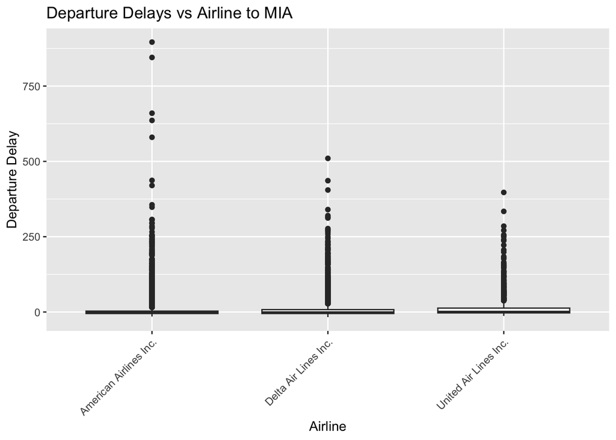

```r
library(ggplot2)

# Filtering flights with destination MIA
mia_flights <- filter(flights, dest == "MIA")

# Joining with airlines to get airline names
mia_flights <- inner_join(mia_flights, airlines, by = "carrier")

# Plotting boxplot
ggplot(mia_flights, aes(x = name, y = dep_delay)) +
  geom_boxplot() +
  labs(x = "Airline", y = "Departure Delay", title = "Departure Delays vs Airline to MIA") +
  theme(axis.text.x = element_text(angle = 45, hjust = 1))
```

### Python solution

You can use [pandas.boxplot()](https://pandas.pydata.org/docs/reference/api/pandas.DataFrame.boxplot.html) or [seaborn.boxplot()](https://seaborn.pydata.org/generated/seaborn.boxplot.html). You can either import data from the R package into Python or use the data Python package [nycflights13](https://pypi.org/project/nycflights13/)

```python
# import python libraries
import pandas as pd
import seaborn as sns
import matplotlib.pyplot as plt

# Load data using nycflights13 package
from nycflights13 import flights, airlines

# Joining flights and airlines data frames
joined_data = flights.merge(airlines, left_on='carrier', right_on='carrier')

# Filtering flights with destination MIA
mia_flights = joined_data[joined_data['dest'] == 'MIA']

# Boxplot
plt.figure(figsize=(10, 6))
sns.boxplot(x='name', y='dep_delay', data=mia_flights)
plt.xlabel('Airline')
plt.ylabel('Departure Delay')
plt.title('Distribution of Departure Delays by Airline for MIA Destination')
plt.xticks(rotation=45)  # Rotate x-axis labels for better readability
```

```
([0, 1, 2], [Text(0, 0, 'American Airlines Inc.'), Text(1, 0, 'United Air Lines Inc.'), Text(2, 0, 'Delta Air Lines Inc.')])
```

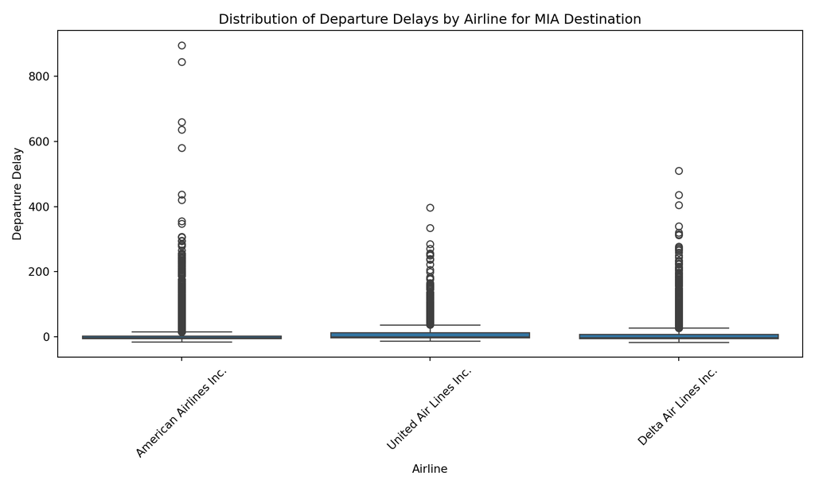

```python
plt.tight_layout()  # Adjust layout to prevent clipping of labels
plt.show()
```

## **Question 3: For each airlines, 1) find the month where the average departure delay time is the highest in the year. 2) Make a visualization to show the results. Solve this question using your preferred language R or Python.**

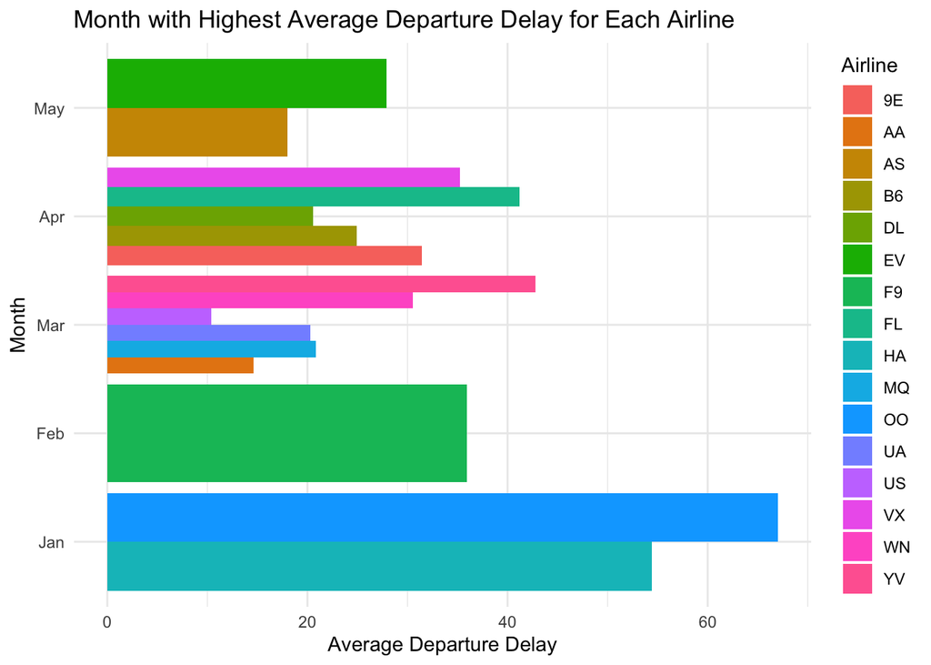

```r
# Load necessary R libraries
library(dplyr)
library(ggplot2)

# Load data using nycflights13 package
flights <- nycflights13::flights
airlines <- nycflights13::airlines

# 1) Find the month with the highest average departure delay for each airline
highest_delay_month <- flights %>%
  group_by(carrier, month) %>%
  summarize(dep_delay = mean(dep_delay, na.rm = TRUE)) %>%
  arrange(carrier, desc(dep_delay)) %>%
  slice(1)

# 2) Visualization
ggplot(highest_delay_month, aes(x = factor(month), y = dep_delay, fill = carrier)) +
  geom_bar(stat = "identity", position = "dodge") +
  labs(x = "Month", y = "Average Departure Delay",
       title = "Month with Highest Average Departure Delay for Each Airline",
       fill = "Airline") +
  theme_minimal() +
  theme(legend.position = "right") +
  guides(fill = guide_legend(title.position = "top", ncol = 1)) +
  scale_x_discrete(labels = month.abb) +
  coord_flip()
```

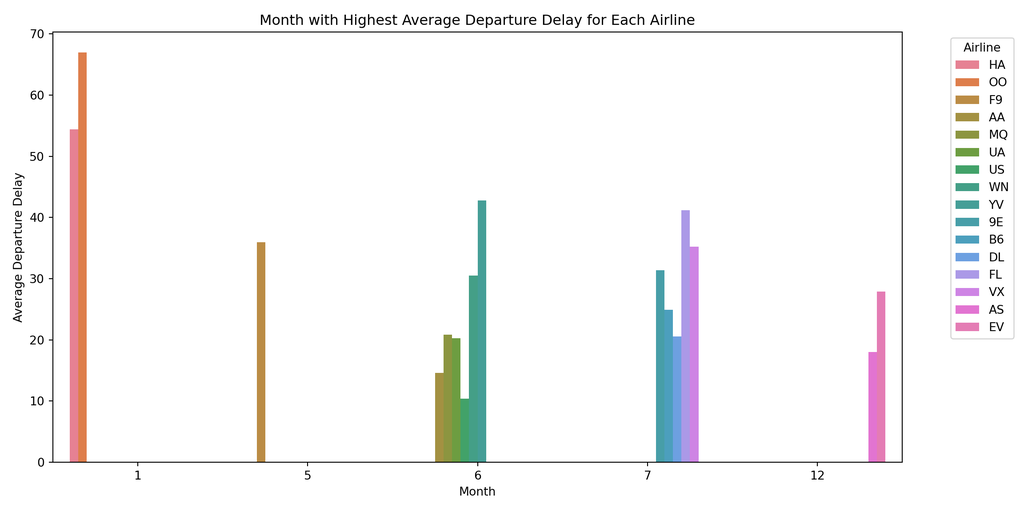

```python
# import python libraries
import pandas as pd
import seaborn as sns
import matplotlib.pyplot as plt

# Load data using nycflights13 package
from nycflights13 import flights, airlines

# 1) Find the month with the highest average departure delay for each airline
highest_delay_month = flights.groupby(['carrier', 'month'])['dep_delay'].mean().reset_index()
highest_delay_month = highest_delay_month.sort_values(by=['carrier', 'dep_delay'], ascending=[True, False])
highest_delay_month = highest_delay_month.drop_duplicates(subset='carrier', keep='first')

# 2) Visualization
plt.figure(figsize=(12, 6))
sns.barplot(x='month', y='dep_delay', hue='carrier', data=highest_delay_month)
plt.xlabel('Month')
plt.ylabel('Average Departure Delay')
plt.title('Month with Highest Average Departure Delay for Each Airline')
plt.legend(title='Airline', bbox_to_anchor=(1.05, 1), loc='upper left')
plt.tight_layout()
plt.show()
```